# WEEK5_Final Project2

2024-08-18

This report is about the analysis of the file “COVID-19 Data” (https://raw.githubusercontent.com/CSSEGISandData/COVID-19/master/csse_covid_19_data/csse_covid_19_time_series/)”

```r
library(conflicted)
library(tidyverse)
library(lubridate)
library(ggplot2)
library(leaflet) # install.packages("leaflet")
```

```r
url_in <- "https://raw.githubusercontent.com/CSSEGISandData/COVID-19/master/csse_covid_19_data/csse_covid_19_time_series/"

file_names <- c("time_series_covid19_confirmed_global.csv",
                "time_series_covid19_deaths_global.csv",
                "time_series_covid19_confirmed_US.csv",
                "time_series_covid19_deaths_US.csv")
urls <- str_c(url_in, file_names)
urls
```

```
## [1] "https://raw.githubusercontent.com/CSSEGISandData/COVID-19/master/csse_covid_19_data/csse_covid_19_time_series/time_series_covid19_confirmed_global.csv"
## [2] "https://raw.githubusercontent.com/CSSEGISandData/COVID-19/master/csse_covid_19_data/csse_covid_19_time_series/time_series_covid19_deaths_global.csv"
## [3] "https://raw.githubusercontent.com/CSSEGISandData/COVID-19/master/csse_covid_19_data/csse_covid_19_time_series/time_series_covid19_confirmed_US.csv"
## [4] "https://raw.githubusercontent.com/CSSEGISandData/COVID-19/master/csse_covid_19_data/csse_covid_19_time_series/time_series_covid19_deaths_US.csv"
```

## Part1. Data Inspecting (What kind of data are we dealing with?)

- “global_cases” and “Global_deaths” have 1147 columns of the data. “US_cases” and “US_deaths” have 1154 columns and 1155 columns of the data.

```r
global_cases <- read_csv(urls[1])
global_deaths <- read_csv(urls[2])
US_cases <- read_csv(urls[3])
US_deaths <- read_csv(urls[4])
```

- Sample data are shown below.

```r
global_cases
```

```
## # A tibble: 289 × 1,147
##    `Province/State`  `Country/Region`   Lat   Long `1/22/20` `1/23/20` `1/24/20`
##    <chr>             <chr>            <dbl>  <dbl>     <dbl>     <dbl>     <dbl>
##  1 <NA>              Afghanistan       33.9  67.7          0         0         0
##  2 <NA>              Albania           41.2  20.2          0         0         0
##  3 <NA>              Algeria           28.0   1.66         0         0         0
##  4 <NA>              Andorra           42.5   1.52         0         0         0
##  5 <NA>              Angola           -11.2  17.9          0         0         0
##  6 <NA>              Antarctica       -71.9  23.3          0         0         0
##  7 <NA>              Antigua and Bar…  17.1 -61.8          0         0         0
##  8 <NA>              Argentina        -38.4 -63.6          0         0         0
##  9 <NA>              Armenia           40.1  45.0          0         0         0
## 10 Australian Capit… Australia        -35.5 149.           0         0         0
## # ℹ 279 more rows
## # ℹ 1,140 more variables: `1/25/20` <dbl>, `1/26/20` <dbl>, `1/27/20` <dbl>,
## #   `1/28/20` <dbl>, `1/29/20` <dbl>, `1/30/20` <dbl>, `1/31/20` <dbl>,
## #   `2/1/20` <dbl>, `2/2/20` <dbl>, `2/3/20` <dbl>, `2/4/20` <dbl>,
## #   `2/5/20` <dbl>, `2/6/20` <dbl>, `2/7/20` <dbl>, `2/8/20` <dbl>,
## #   `2/9/20` <dbl>, `2/10/20` <dbl>, `2/11/20` <dbl>, `2/12/20` <dbl>,
## #   `2/13/20` <dbl>, `2/14/20` <dbl>, `2/15/20` <dbl>, `2/16/20` <dbl>, …
```

- Converts the columns specified in the argument cols to vertical data by using pivot_longer function.

```r
global_cases <- global_cases %>%
     pivot_longer(cols = -c('Province/State', 'Country/Region', Lat, Long),
                  names_to = "date", values_to = "cases") %>%
     select(-c()) #select(-c(Lat, Long))
global_cases
```

```
## # A tibble: 330,327 × 6
##    `Province/State` `Country/Region`   Lat  Long date    cases
##    <chr>            <chr>            <dbl> <dbl> <chr>   <dbl>
##  1 <NA>             Afghanistan       33.9  67.7 1/22/20     0
##  2 <NA>             Afghanistan       33.9  67.7 1/23/20     0
##  3 <NA>             Afghanistan       33.9  67.7 1/24/20     0
##  4 <NA>             Afghanistan       33.9  67.7 1/25/20     0
##  5 <NA>             Afghanistan       33.9  67.7 1/26/20     0
##  6 <NA>             Afghanistan       33.9  67.7 1/27/20     0
##  7 <NA>             Afghanistan       33.9  67.7 1/28/20     0
##  8 <NA>             Afghanistan       33.9  67.7 1/29/20     0
##  9 <NA>             Afghanistan       33.9  67.7 1/30/20     0
## 10 <NA>             Afghanistan       33.9  67.7 1/31/20     0
## # ℹ 330,317 more rows
```

```r
global_deaths <- global_deaths %>%
     pivot_longer(cols = -c('Province/State', 'Country/Region', Lat, Long),
                  names_to = "date", values_to = "deaths") %>%
     select(-c()) #select(-c(Lat, Long))
global_deaths
```

```
## # A tibble: 330,327 × 6
##    `Province/State` `Country/Region`   Lat  Long date    deaths
##    <chr>            <chr>            <dbl> <dbl> <chr>    <dbl>
##  1 <NA>             Afghanistan       33.9  67.7 1/22/20      0
##  2 <NA>             Afghanistan       33.9  67.7 1/23/20      0
##  3 <NA>             Afghanistan       33.9  67.7 1/24/20      0
##  4 <NA>             Afghanistan       33.9  67.7 1/25/20      0
##  5 <NA>             Afghanistan       33.9  67.7 1/26/20      0
##  6 <NA>             Afghanistan       33.9  67.7 1/27/20      0
##  7 <NA>             Afghanistan       33.9  67.7 1/28/20      0
##  8 <NA>             Afghanistan       33.9  67.7 1/29/20      0
##  9 <NA>             Afghanistan       33.9  67.7 1/30/20      0
## 10 <NA>             Afghanistan       33.9  67.7 1/31/20      0
## # ℹ 330,317 more rows
```

- Combine “global_cases” and “global_deaths”. By doing so, we can check the number of cases and deaths by region and date.

```r
global <- global_cases %>%
     full_join(global_deaths) %>%
     rename(Country_Region ='Country/Region',
            Province_State = 'Province/State') %>%
     mutate(date = mdy(date))
global
```

```
## # A tibble: 330,327 × 7
##    Province_State Country_Region   Lat  Long date       cases deaths
##    <chr>          <chr>          <dbl> <dbl> <date>     <dbl>  <dbl>
##  1 <NA>           Afghanistan     33.9  67.7 2020-01-22     0      0
##  2 <NA>           Afghanistan     33.9  67.7 2020-01-23     0      0
##  3 <NA>           Afghanistan     33.9  67.7 2020-01-24     0      0
##  4 <NA>           Afghanistan     33.9  67.7 2020-01-25     0      0
##  5 <NA>           Afghanistan     33.9  67.7 2020-01-26     0      0
##  6 <NA>           Afghanistan     33.9  67.7 2020-01-27     0      0
##  7 <NA>           Afghanistan     33.9  67.7 2020-01-28     0      0
##  8 <NA>           Afghanistan     33.9  67.7 2020-01-29     0      0
##  9 <NA>           Afghanistan     33.9  67.7 2020-01-30     0      0
## 10 <NA>           Afghanistan     33.9  67.7 2020-01-31     0      0
## # ℹ 330,317 more rows
```

- Below is a summary of “global”. Lat column and Long column in “global” have NA records.

```r
summary(global)
```

```
##  Province_State     Country_Region          Lat               Long
##  Length:330327      Length:330327      Min.   :-71.950   Min.   :-178.12
##  Class :character   Class :character   1st Qu.:  3.934   1st Qu.: -42.60
##  Mode  :character   Mode  :character   Median : 21.513   Median :  20.94
##                                        Mean   : 19.719   Mean   :  22.18
##                                        3rd Qu.: 40.464   3rd Qu.:  90.36
##                                        Max.   : 71.707   Max.   : 178.06
##                                        NA's   :2286      NA's   :2286
##       date                cases               deaths
##  Min.   :2020-01-22   Min.   :        0   Min.   :      0
##  1st Qu.:2020-11-02   1st Qu.:      680   1st Qu.:      3
##  Median :2021-08-15   Median :    14429   Median :    150
##  Mean   :2021-08-15   Mean   :   959384   Mean   :  13380
##  3rd Qu.:2022-05-28   3rd Qu.:   228517   3rd Qu.:   3032
##  Max.   :2023-03-09   Max.   :103802702   Max.   :1123836
##
```

- NA values in Lat and Long are complemented with 0.

```r
global <- mutate_if(global, is.numeric, ~replace(., is.na(.), 0))
summary(global)
```

```
##  Province_State     Country_Region          Lat               Long
##  Length:330327      Length:330327      Min.   :-71.950   Min.   :-178.12
##  Class :character   Class :character   1st Qu.:  3.919   1st Qu.: -23.04
##  Mode  :character   Mode  :character   Median : 21.008   Median :  20.90
##                                        Mean   : 19.582   Mean   :  22.03
##                                        3rd Qu.: 40.340   3rd Qu.:  88.09
##                                        Max.   : 71.707   Max.   : 178.06
##       date                cases               deaths
##  Min.   :2020-01-22   Min.   :        0   Min.   :      0
##  1st Qu.:2020-11-02   1st Qu.:      680   1st Qu.:      3
##  Median :2021-08-15   Median :    14429   Median :    150
##  Mean   :2021-08-15   Mean   :   959384   Mean   :  13380
##  3rd Qu.:2022-05-28   3rd Qu.:   228517   3rd Qu.:   3032
##  Max.   :2023-03-09   Max.   :103802702   Max.   :1123836
```

- Filtering so that only cases greater than to 0 are considered.

```r
global <- global %>% dplyr::filter(cases > 0)
global
```

```
## # A tibble: 306,827 × 7
##    Province_State Country_Region   Lat  Long date       cases deaths
##    <chr>          <chr>          <dbl> <dbl> <date>     <dbl>  <dbl>
##  1 <NA>           Afghanistan     33.9  67.7 2020-02-24     5      0
##  2 <NA>           Afghanistan     33.9  67.7 2020-02-25     5      0
##  3 <NA>           Afghanistan     33.9  67.7 2020-02-26     5      0
##  4 <NA>           Afghanistan     33.9  67.7 2020-02-27     5      0
##  5 <NA>           Afghanistan     33.9  67.7 2020-02-28     5      0
##  6 <NA>           Afghanistan     33.9  67.7 2020-02-29     5      0
##  7 <NA>           Afghanistan     33.9  67.7 2020-03-01     5      0
##  8 <NA>           Afghanistan     33.9  67.7 2020-03-02     5      0
##  9 <NA>           Afghanistan     33.9  67.7 2020-03-03     5      0
## 10 <NA>           Afghanistan     33.9  67.7 2020-03-04     5      0
## # ℹ 306,817 more rows
```

```r
summary(global)
```

```
##  Province_State     Country_Region          Lat              Long
##  Length:306827      Length:306827      Min.   :-71.95   Min.   :-178.12
##  Class :character   Class :character   1st Qu.:  4.86   1st Qu.: -19.02
##  Mode  :character   Mode  :character   Median : 21.92   Median :  20.94
##                                        Mean   : 20.40   Mean   :  23.01
##                                        3rd Qu.: 41.11   3rd Qu.:  88.09
##                                        Max.   : 71.71   Max.   : 178.06
##       date                cases               deaths
##  Min.   :2020-01-22   Min.   :        1   Min.   :      0
##  1st Qu.:2020-12-12   1st Qu.:     1316   1st Qu.:      7
##  Median :2021-09-16   Median :    20365   Median :    214
##  Mean   :2021-09-11   Mean   :  1032863   Mean   :  14405
##  3rd Qu.:2022-06-15   3rd Qu.:   271281   3rd Qu.:   3665
##  Max.   :2023-03-09   Max.   :103802702   Max.   :1123836
```

- In the following, I will do for U.S. data what I did for global data.

```r
US_cases
```

```
## # A tibble: 3,342 × 1,154
##         UID iso2  iso3  code3  FIPS Admin2   Province_State Country_Region   Lat
##       <dbl> <chr> <chr> <dbl> <dbl> <chr>    <chr>          <chr>          <dbl>
##  1 84001001 US    USA     840  1001 Autauga  Alabama        US              32.5
##  2 84001003 US    USA     840  1003 Baldwin  Alabama        US              30.7
##  3 84001005 US    USA     840  1005 Barbour  Alabama        US              31.9
##  4 84001007 US    USA     840  1007 Bibb     Alabama        US              33.0
##  5 84001009 US    USA     840  1009 Blount   Alabama        US              34.0
##  6 84001011 US    USA     840  1011 Bullock  Alabama        US              32.1
##  7 84001013 US    USA     840  1013 Butler   Alabama        US              31.8
##  8 84001015 US    USA     840  1015 Calhoun  Alabama        US              33.8
##  9 84001017 US    USA     840  1017 Chambers Alabama        US              32.9
## 10 84001019 US    USA     840  1019 Cherokee Alabama        US              34.2
## # ℹ 3,332 more rows
## # ℹ 1,145 more variables: Long_ <dbl>, Combined_Key <chr>, `1/22/20` <dbl>,
## #   `1/23/20` <dbl>, `1/24/20` <dbl>, `1/25/20` <dbl>, `1/26/20` <dbl>,
## #   `1/27/20` <dbl>, `1/28/20` <dbl>, `1/29/20` <dbl>, `1/30/20` <dbl>,
## #   `1/31/20` <dbl>, `2/1/20` <dbl>, `2/2/20` <dbl>, `2/3/20` <dbl>,
## #   `2/4/20` <dbl>, `2/5/20` <dbl>, `2/6/20` <dbl>, `2/7/20` <dbl>,
## #   `2/8/20` <dbl>, `2/9/20` <dbl>, `2/10/20` <dbl>, `2/11/20` <dbl>, …
```

```r
US_cases <- US_cases %>%
    pivot_longer(cols = -(UID:Combined_Key),
                 names_to = "date",
                 values_to = "cases") %>%
    select(Admin2:cases) %>%
    mutate(date = mdy(date)) %>%
    select(-c()) #select(-c(Lat, Long_))
US_cases
```

```
## # A tibble: 3,819,906 × 8
##    Admin2  Province_State Country_Region   Lat Long_ Combined_Key     date
##    <chr>   <chr>          <chr>          <dbl> <dbl> <chr>            <date>
##  1 Autauga Alabama        US              32.5 -86.6 Autauga, Alabam… 2020-01-22
##  2 Autauga Alabama        US              32.5 -86.6 Autauga, Alabam… 2020-01-23
##  3 Autauga Alabama        US              32.5 -86.6 Autauga, Alabam… 2020-01-24
##  4 Autauga Alabama        US              32.5 -86.6 Autauga, Alabam… 2020-01-25
##  5 Autauga Alabama        US              32.5 -86.6 Autauga, Alabam… 2020-01-26
##  6 Autauga Alabama        US              32.5 -86.6 Autauga, Alabam… 2020-01-27
##  7 Autauga Alabama        US              32.5 -86.6 Autauga, Alabam… 2020-01-28
##  8 Autauga Alabama        US              32.5 -86.6 Autauga, Alabam… 2020-01-29
##  9 Autauga Alabama        US              32.5 -86.6 Autauga, Alabam… 2020-01-30
## 10 Autauga Alabama        US              32.5 -86.6 Autauga, Alabam… 2020-01-31
## # ℹ 3,819,896 more rows
## # ℹ 1 more variable: cases <dbl>
```

```r
US_deaths <- US_deaths %>%
    pivot_longer(cols = -(UID:Population),
                 names_to = "date",
                 values_to = "deaths") %>%
    select(Admin2:deaths) %>%
    mutate(date = mdy(date)) %>%
    select(-c()) #select(-c(Lat, Long_))
US_deaths
```

```
## # A tibble: 3,819,906 × 9
##    Admin2  Province_State Country_Region   Lat Long_ Combined_Key     Population
##    <chr>   <chr>          <chr>          <dbl> <dbl> <chr>                 <dbl>
##  1 Autauga Alabama        US              32.5 -86.6 Autauga, Alabam…      55869
##  2 Autauga Alabama        US              32.5 -86.6 Autauga, Alabam…      55869
##  3 Autauga Alabama        US              32.5 -86.6 Autauga, Alabam…      55869
##  4 Autauga Alabama        US              32.5 -86.6 Autauga, Alabam…      55869
##  5 Autauga Alabama        US              32.5 -86.6 Autauga, Alabam…      55869
##  6 Autauga Alabama        US              32.5 -86.6 Autauga, Alabam…      55869
##  7 Autauga Alabama        US              32.5 -86.6 Autauga, Alabam…      55869
##  8 Autauga Alabama        US              32.5 -86.6 Autauga, Alabam…      55869
##  9 Autauga Alabama        US              32.5 -86.6 Autauga, Alabam…      55869
## 10 Autauga Alabama        US              32.5 -86.6 Autauga, Alabam…      55869
## # ℹ 3,819,896 more rows
## # ℹ 2 more variables: date <date>, deaths <dbl>
```

```r
US <- US_cases %>%
   full_join(US_deaths)
US
```

```
## # A tibble: 3,819,906 × 10
##    Admin2  Province_State Country_Region   Lat Long_ Combined_Key     date
##    <chr>   <chr>          <chr>          <dbl> <dbl> <chr>            <date>
##  1 Autauga Alabama        US              32.5 -86.6 Autauga, Alabam… 2020-01-22
##  2 Autauga Alabama        US              32.5 -86.6 Autauga, Alabam… 2020-01-23
##  3 Autauga Alabama        US              32.5 -86.6 Autauga, Alabam… 2020-01-24
##  4 Autauga Alabama        US              32.5 -86.6 Autauga, Alabam… 2020-01-25
##  5 Autauga Alabama        US              32.5 -86.6 Autauga, Alabam… 2020-01-26
##  6 Autauga Alabama        US              32.5 -86.6 Autauga, Alabam… 2020-01-27
##  7 Autauga Alabama        US              32.5 -86.6 Autauga, Alabam… 2020-01-28
##  8 Autauga Alabama        US              32.5 -86.6 Autauga, Alabam… 2020-01-29
##  9 Autauga Alabama        US              32.5 -86.6 Autauga, Alabam… 2020-01-30
## 10 Autauga Alabama        US              32.5 -86.6 Autauga, Alabam… 2020-01-31
## # ℹ 3,819,896 more rows
## # ℹ 3 more variables: cases <dbl>, Population <dbl>, deaths <dbl>
```

- Create a new column with Province_State and Country_Region.

```r
global <- global %>%
    unite("Combined_Key",
          c(Province_State, Country_Region),
          sep = ", ",
          na.rm = TRUE,
          remove = FALSE)
global
```

```
## # A tibble: 306,827 × 8
##    Combined_Key Province_State Country_Region   Lat  Long date       cases
##    <chr>        <chr>          <chr>          <dbl> <dbl> <date>     <dbl>
##  1 Afghanistan  <NA>           Afghanistan     33.9  67.7 2020-02-24     5
##  2 Afghanistan  <NA>           Afghanistan     33.9  67.7 2020-02-25     5
##  3 Afghanistan  <NA>           Afghanistan     33.9  67.7 2020-02-26     5
##  4 Afghanistan  <NA>           Afghanistan     33.9  67.7 2020-02-27     5
##  5 Afghanistan  <NA>           Afghanistan     33.9  67.7 2020-02-28     5
##  6 Afghanistan  <NA>           Afghanistan     33.9  67.7 2020-02-29     5
##  7 Afghanistan  <NA>           Afghanistan     33.9  67.7 2020-03-01     5
##  8 Afghanistan  <NA>           Afghanistan     33.9  67.7 2020-03-02     5
##  9 Afghanistan  <NA>           Afghanistan     33.9  67.7 2020-03-03     5
## 10 Afghanistan  <NA>           Afghanistan     33.9  67.7 2020-03-04     5
## # ℹ 306,817 more rows
## # ℹ 1 more variable: deaths <dbl>
```

## Part2. Scatter plot of the cases (What is the distribution of the number of infection?)

- Below is a scatter plot of the number of cases at latitude and longitude. Plotted at two time points, 2020-02-28 and 2023-02-28, I see a general increase in the number of cases. However, since this figure only shows latitude and longitude, it does not provide information on which countries the increase is occurring in.

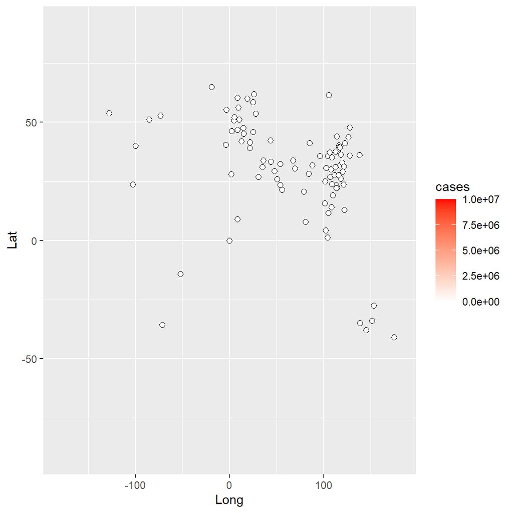

```r
min_value1 <- -90
max_value1 <- 90
min_value2 <- -180
max_value2 <- 180
limit <- 10000000

global2 <- global %>% dplyr::filter(date == "2020-02-28")
ggplot(global2,aes(x=Long, y=Lat, fill=cases)) +
geom_point(shape=21, size=2.0) +
scale_fill_gradient(low = "white",high = "red", limits = c(0, limit)) +
scale_x_continuous(limits = c(min_value2, max_value2)) +
scale_y_continuous(limits = c(min_value1, max_value1))
```

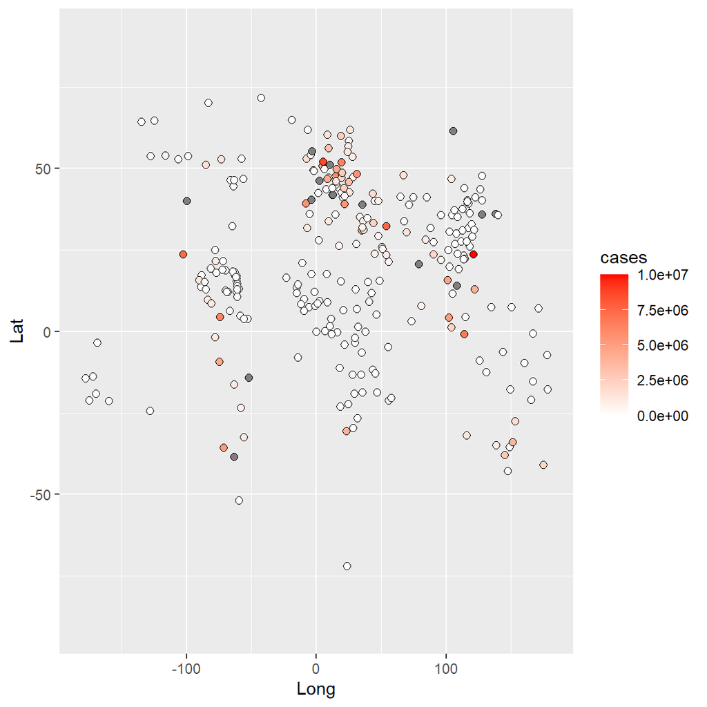

```r
global2 <- global %>% dplyr::filter(date == "2023-02-28")
ggplot(global2,aes(x=Long, y=Lat, fill=cases)) +
geom_point(shape=21, size=2.0) +
scale_fill_gradient(low = "white",high = "red", limits = c(0, limit)) +
scale_x_continuous(limits = c(min_value2, max_value2)) +
scale_y_continuous(limits = c(min_value1, max_value1))
```

- So I used leaflet to merge the world map with a scatter plot of latitude and longitude. Leaflet is an open-source JavaScript library for interactive maps. This R package makes it easy to create Leaflet maps from R. https://rstudio.github.io/leaflet/articles/leaflet.html
- The results of plotting the number of cases for 2020-02-28 and 2023-02-28 on a world map using Leaflet are shown below. The difference between the early and late stages of the covid-19 in the number of cases per country can be seen. In the early stage, only China had many cases of infection. In the late stage, the United States has the highest number of cases, and other large cities with large populations, such as India, Brazil, France, and Japan, have many number of infections.

```r
global2 <- global %>% dplyr::filter(date == "2020-02-28")
m <- leaflet(global2) %>%
  addTiles() %>%
  setView(lng=30,lat=0,zoom=2)
pal2 <- colorNumeric(palette = "YlOrRd", domain = global2$cases)
m %>%
  addCircleMarkers(~Long, ~Lat, color = ~pal2(cases), fillOpacity = 1, stroke = F, radius = 5) %>%
  addLegend(position='bottomleft', pal = pal2, values = ~cases)
```

[interactive chart not shown]

```r
global2 <- global %>% dplyr::filter(date == "2023-02-28")
m <- leaflet(global2) %>%
  addTiles() %>%
  setView(lng=30,lat=0,zoom=2)
pal2 <- colorNumeric(palette = "YlOrRd", domain = global2$cases)
m %>%
  addCircleMarkers(~Long, ~Lat, color = ~pal2(cases), fillOpacity = 1, stroke = F, radius = 5) %>%
  addLegend(position='bottomleft', pal = pal2, values = ~cases)
```

[interactive chart not shown]

- The number of cases in the US is plotted on the map as well.

```r
US2 <- US %>% dplyr::filter(date == "2020-02-28")
m <- leaflet(US2) %>%
  addTiles() %>%
  setView(lng=-97,lat=38,zoom=4)
pal2 <- colorNumeric(palette = "YlOrRd", domain = US2$cases)
m %>%
  addCircleMarkers(~Long_, ~Lat, color = ~pal2(cases), fillOpacity = 1, stroke = F, radius = 3) %>%
  addLegend(position='bottomleft', pal = pal2, values = ~cases)
```

[interactive chart not shown]

```r
US2 <- US %>% dplyr::filter(date == "2023-02-28")
m <- leaflet(US2) %>%
  addTiles() %>%
  setView(lng=-97,lat=38,zoom=4)
pal2 <- colorNumeric(palette = "YlOrRd", domain = US2$cases)
m %>%
  addCircleMarkers(~Long_, ~Lat, color = ~pal2(cases), fillOpacity = 1, stroke = F, radius = 3) %>%
  addLegend(position='bottomleft', pal = pal2, values = ~cases)
```

[interactive chart not shown]

## Part3. Checking the histrical trend (What is the time-series trend in the number of infection?)

- Use an additional data to add country-specific population information.

```r
uid_lookup_url <- "https://raw.githubusercontent.com/CSSEGISandData/COVID-19/master/csse_covid_19_data/UID_ISO_FIPS_LookUp_Table.csv"

uid <- read_csv(uid_lookup_url) %>%
    select(-c(Lat, Long_, Combined_Key, code3, iso2, iso3, Admin2))
uid
```

```
## # A tibble: 4,321 × 5
##      UID FIPS  Province_State Country_Region      Population
##    <dbl> <chr> <chr>          <chr>                    <dbl>
##  1     4 <NA>  <NA>           Afghanistan           38928341
##  2     8 <NA>  <NA>           Albania                2877800
##  3    10 <NA>  <NA>           Antarctica                  NA
##  4    12 <NA>  <NA>           Algeria               43851043
##  5    20 <NA>  <NA>           Andorra                  77265
##  6    24 <NA>  <NA>           Angola                32866268
##  7    28 <NA>  <NA>           Antigua and Barbuda      97928
##  8    32 <NA>  <NA>           Argentina             45195777
##  9    51 <NA>  <NA>           Armenia                2963234
## 10    40 <NA>  <NA>           Austria                9006400
## # ℹ 4,311 more rows
```

- Merge population column into “global” data.

```r
global <- global %>%
    left_join(uid, by = c("Province_State", "Country_Region")) %>%
    select(-c(UID, FIPS)) %>%
    select(Province_State, Country_Region, date, cases, deaths, Population, Combined_Key)
global
```

```
## # A tibble: 306,827 × 7
##    Province_State Country_Region date       cases deaths Population Combined_Key
##    <chr>          <chr>          <date>     <dbl>  <dbl>      <dbl> <chr>
##  1 <NA>           Afghanistan    2020-02-24     5      0   38928341 Afghanistan
##  2 <NA>           Afghanistan    2020-02-25     5      0   38928341 Afghanistan
##  3 <NA>           Afghanistan    2020-02-26     5      0   38928341 Afghanistan
##  4 <NA>           Afghanistan    2020-02-27     5      0   38928341 Afghanistan
##  5 <NA>           Afghanistan    2020-02-28     5      0   38928341 Afghanistan
##  6 <NA>           Afghanistan    2020-02-29     5      0   38928341 Afghanistan
##  7 <NA>           Afghanistan    2020-03-01     5      0   38928341 Afghanistan
##  8 <NA>           Afghanistan    2020-03-02     5      0   38928341 Afghanistan
##  9 <NA>           Afghanistan    2020-03-03     5      0   38928341 Afghanistan
## 10 <NA>           Afghanistan    2020-03-04     5      0   38928341 Afghanistan
## # ℹ 306,817 more rows
```

- Group data by “Province_State” (state or region), “Country_Region” (country or region), and “date” (date). Within each group, calculate the sum of “cases” (number of cases) and “deaths” (number of deaths). At the same time, the “Population” totals are calculated. Add “deaths_per_mill” (deaths per million) to each row. Divide the number of deaths by the population to compute the number of deaths per million.

```r
US_by_state <- US %>%
    group_by(Province_State, Country_Region, date) %>%
    summarize(cases = sum(cases), deaths = sum(deaths),
              Population = sum(Population)) %>%
    mutate(deaths_per_mill = deaths *1000000 / Population) %>%
    select(Province_State, Country_Region, date,
           cases, deaths, deaths_per_mill, Population) %>%
    ungroup()
US_by_state
```

```
## # A tibble: 66,294 × 7
##    Province_State Country_Region date       cases deaths deaths_per_mill
##    <chr>          <chr>          <date>     <dbl>  <dbl>           <dbl>
##  1 Alabama        US             2020-01-22     0      0               0
##  2 Alabama        US             2020-01-23     0      0               0
##  3 Alabama        US             2020-01-24     0      0               0
##  4 Alabama        US             2020-01-25     0      0               0
##  5 Alabama        US             2020-01-26     0      0               0
##  6 Alabama        US             2020-01-27     0      0               0
##  7 Alabama        US             2020-01-28     0      0               0
##  8 Alabama        US             2020-01-29     0      0               0
##  9 Alabama        US             2020-01-30     0      0               0
## 10 Alabama        US             2020-01-31     0      0               0
## # ℹ 66,284 more rows
## # ℹ 1 more variable: Population <dbl>
```

```r
US_totals <- US_by_state %>%
    group_by(Country_Region, date) %>%
    summarize(cases = sum(cases), deaths = sum(deaths),
              Population = sum(Population)) %>%
    mutate(deaths_per_mill = deaths *1000000 / Population) %>%
    select(Country_Region, date,
           cases, deaths, deaths_per_mill, Population) %>%
    ungroup()
US_totals
```

```
## # A tibble: 1,143 × 6
##    Country_Region date       cases deaths deaths_per_mill Population
##    <chr>          <date>     <dbl>  <dbl>           <dbl>      <dbl>
##  1 US             2020-01-22     1      1         0.00300  332875137
##  2 US             2020-01-23     1      1         0.00300  332875137
##  3 US             2020-01-24     2      1         0.00300  332875137
##  4 US             2020-01-25     2      1         0.00300  332875137
##  5 US             2020-01-26     5      1         0.00300  332875137
##  6 US             2020-01-27     5      1         0.00300  332875137
##  7 US             2020-01-28     5      1         0.00300  332875137
##  8 US             2020-01-29     6      1         0.00300  332875137
##  9 US             2020-01-30     6      1         0.00300  332875137
## 10 US             2020-01-31     8      1         0.00300  332875137
## # ℹ 1,133 more rows
```

- Below are the cases and the number of deaths across the U.S.

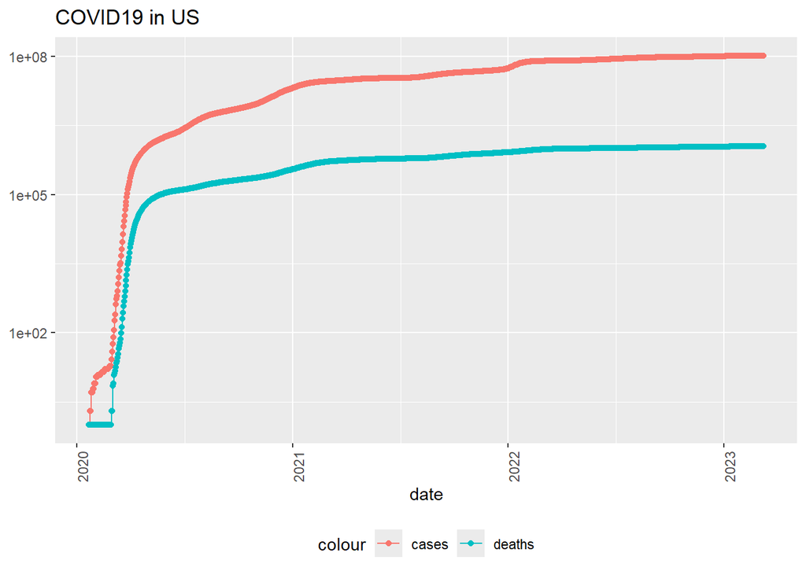

```r
US_totals %>%
    dplyr::filter(cases > 0) %>%
    ggplot(aes(x = date, y = cases)) +
    geom_line(aes(color = "cases")) +
    geom_point(aes(color = "cases")) +
    geom_line(aes(y = deaths, color = "deaths")) +
    geom_point(aes(y = deaths, color = "deaths")) +
    scale_y_log10() +
    theme(legend.position="bottom",
          axis.text.x = element_text(angle = 90)) +
    labs(title = "COVID19 in US", y= NULL)
```

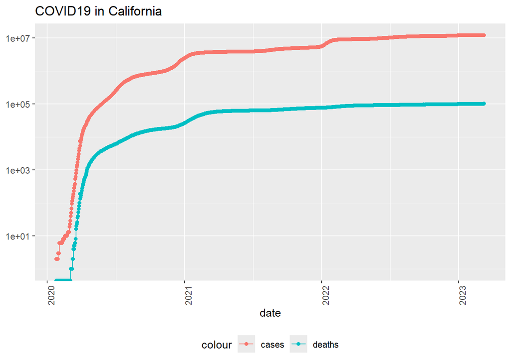

```r
state <- "California"
US_by_state %>%
    dplyr::filter(Province_State == state) %>%
    dplyr::filter(cases > 0) %>%
    ggplot(aes(x = date, y = cases)) +
    geom_line(aes(color = "cases")) +
    geom_point(aes(color = "cases")) +
    geom_line(aes(y = deaths, color = "deaths")) +
    geom_point(aes(y = deaths, color = "deaths")) +
    scale_y_log10() +
    theme(legend.position="bottom",
          axis.text.x = element_text(angle = 90)) +
    labs(title = "COVID19 in California", y= NULL)
```

- Highest number of deaths in US total.

[output not shown]

- Add the new_cases column and new_deaths column which express difference from the previous day. (lag function -> Shift x backward by n)

```r
US_by_state <- US_by_state %>%
     mutate(new_cases = cases - dplyr::lag(cases),
            new_deaths = deaths - dplyr::lag(deaths))
US_totals <- US_totals %>%
     mutate(new_cases = cases - dplyr::lag(cases),
            new_deaths = deaths - dplyr::lag(deaths))

tail(US_totals)
```

```
## # A tibble: 6 × 8
##   Country_Region date          cases deaths deaths_per_mill Population new_cases
##   <chr>          <date>        <dbl>  <dbl>           <dbl>      <dbl>     <dbl>
## 1 US             2023-03-04   1.04e8 1.12e6           3371.  332875137      2147
## 2 US             2023-03-05   1.04e8 1.12e6           3371.  332875137     -3862
## 3 US             2023-03-06   1.04e8 1.12e6           3371.  332875137      8564
## 4 US             2023-03-07   1.04e8 1.12e6           3372.  332875137     35371
## 5 US             2023-03-08   1.04e8 1.12e6           3374.  332875137     64861
## 6 US             2023-03-09   1.04e8 1.12e6           3376.  332875137     46931
## # ℹ 1 more variable: new_deaths <dbl>
```

```r
#tail(US_totals %>% select(new_cases, new_deaths, everything()))
```

- The historical trends for the new_cases and new_deaths are as follows.

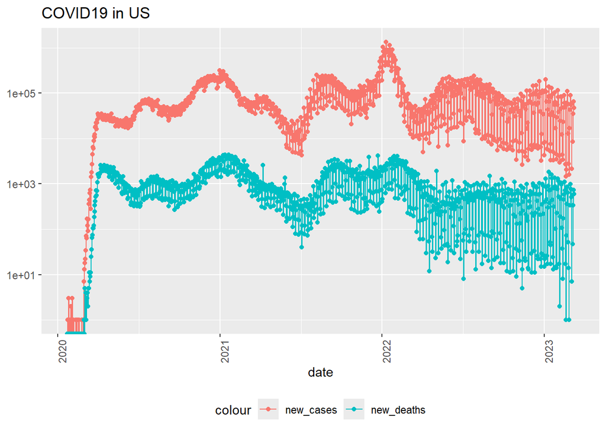

```r
US_totals %>%
    ggplot(aes(x = date, y = new_cases)) +
    geom_line(aes(color = "new_cases")) +
    geom_point(aes(color = "new_cases")) +
    geom_line(aes(y = new_deaths, color = "new_deaths")) +
    geom_point(aes(y = new_deaths, color = "new_deaths")) +
    scale_y_log10() +
    theme(legend.position="bottom",
          axis.text.x = element_text(angle = 90)) +
    labs(title = "COVID19 in US", y= NULL)
```

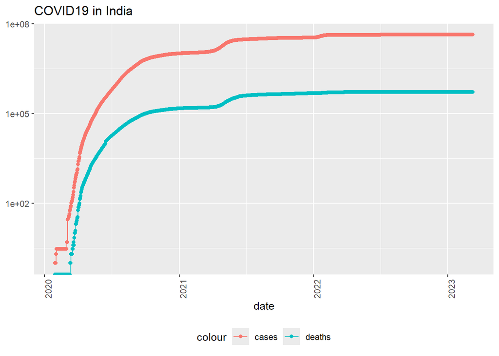

```r
global_totals <- global %>%
    group_by(Country_Region, date) %>%
    summarize(cases = sum(cases), deaths = sum(deaths),
              Population = sum(Population)) %>%
    mutate(deaths_per_mill = deaths *1000000 / Population) %>%
    select(Country_Region, date,
           cases, deaths, deaths_per_mill, Population) %>%
    ungroup()
#global_totals

country <- "India"
global_totals %>%
    dplyr::filter(Country_Region == country) %>%
    dplyr::filter(cases > 0) %>%
    ggplot(aes(x = date, y = cases)) +
    geom_line(aes(color = "cases")) +
    geom_point(aes(color = "cases")) +
    geom_line(aes(y = deaths, color = "deaths")) +
    geom_point(aes(y = deaths, color = "deaths")) +
    scale_y_log10() +
    theme(legend.position="bottom",
          axis.text.x = element_text(angle = 90)) +
    labs(title = "COVID19 in India", y= NULL)
```

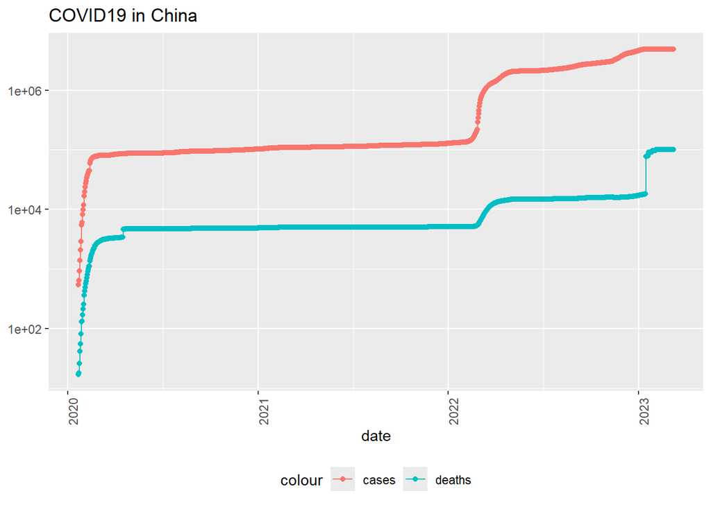

```r
country <- "China"
global_totals %>%
    dplyr::filter(Country_Region == country) %>%
    dplyr::filter(cases > 0) %>%
    ggplot(aes(x = date, y = cases)) +
    geom_line(aes(color = "cases")) +
    geom_point(aes(color = "cases")) +
    geom_line(aes(y = deaths, color = "deaths")) +
    geom_point(aes(y = deaths, color = "deaths")) +
    scale_y_log10() +
    theme(legend.position="bottom",
          axis.text.x = element_text(angle = 90)) +
    labs(title = "COVID19 in China", y= NULL)
```

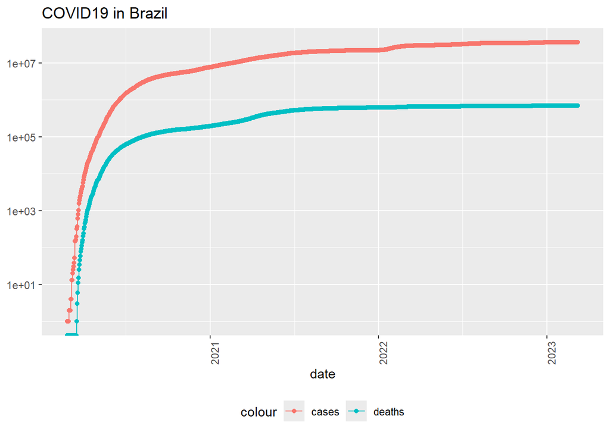

```r
country <- "Brazil"
global_totals %>%
    dplyr::filter(Country_Region == country) %>%
    dplyr::filter(cases > 0) %>%
    ggplot(aes(x = date, y = cases)) +
    geom_line(aes(color = "cases")) +
    geom_point(aes(color = "cases")) +
    geom_line(aes(y = deaths, color = "deaths")) +
    geom_point(aes(y = deaths, color = "deaths")) +
    scale_y_log10() +
    theme(legend.position="bottom",
          axis.text.x = element_text(angle = 90)) +
    labs(title = "COVID19 in Brazil", y= NULL)
```

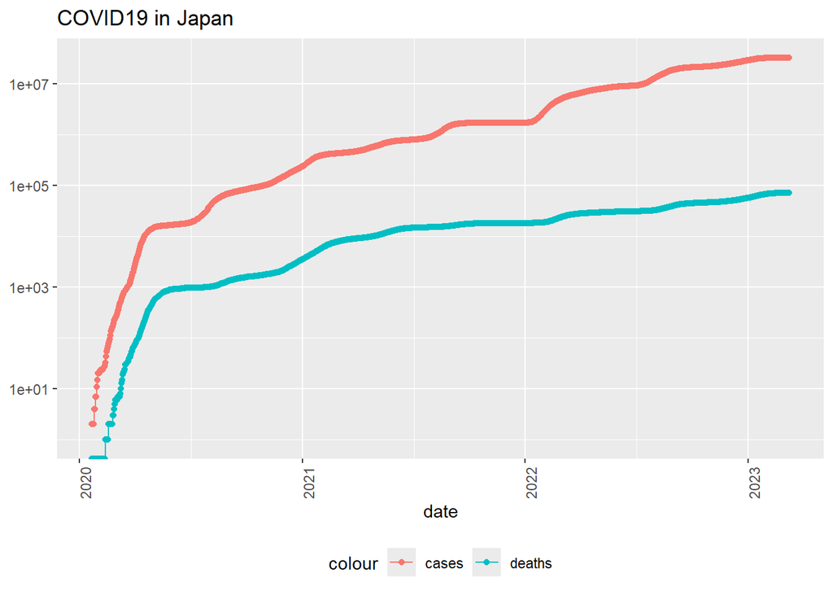

```r
country <- "Japan"
global_totals %>%
    dplyr::filter(Country_Region == country) %>%
    dplyr::filter(cases > 0) %>%
    ggplot(aes(x = date, y = cases)) +
    geom_line(aes(color = "cases")) +
    geom_point(aes(color = "cases")) +
    geom_line(aes(y = deaths, color = "deaths")) +
    geom_point(aes(y = deaths, color = "deaths")) +
    scale_y_log10() +
    theme(legend.position="bottom",
          axis.text.x = element_text(angle = 90)) +
    labs(title = "COVID19 in Japan", y= NULL)
```